# CS 422 HW1

Ramesh Chandra Reddy Musilanna

## 1. Exercises

### Part 1.1

##### Tan, Chapter 1

###### Besides the lecture, make sure you read Chapter 1. After doing so, answer the following questions at the end of the chapter: 1, 3.

Question 1. Discuss whether or not each of the following activities is a data mining task.

Answer:

(a)It is a Database query not a data mining task.

(b)It is an accounts statistically problem not a data mining task.

(c)It is an accounts calculation not a data mining task.

(d)It is a Database query not a data mining task.

(e)It is a probability problem not a data mining task.

(f)It is a Data mining task as it can be solved using regression techniques.

(g)It is a Data mining task as it can be solved using detection model.

(h)It is a Data mining task as it can be solved using detection model.

(i)It is not a data mining task. It is signal processing task.

Question 3. For each of the following data sets, explain whether or not data privacy is an important issue.

Answer:

(a)No, Census data is public.

(b)Yes, IP address information is specific to user.

(c)No, Images from Earth-orbiting satellites are accessible to public on some level and Space agencies.

(d)No, Names and addresses of people are public accessible.

(e)No, Names and email addresses collected from the Web.

### Part 1.2

##### Tan, Chapter 2

###### Besides the lecture, make sure you read Chapter 2, sections 2.1 – 2.3. After doing so, answer the following questions at the end of the chapter: 2, 3, 7, 12.

Question 2. Classify the following attributes as binary, discrete, or continuous. Also classify them as qualitative (nominal or ordinal) or quantitative (interval or ratio).Some cases may have more than one interpretation, so briefly indicate your reasoning if you think there may be some ambiguity.

Answer:

(a)Time in terms of AM or PM. - Ordinal, Binary.

(b)Brightness as measured by a light meter. - Ratio, Continuous.

(c)Brightness as measured by people’s judgments. - Discrete, Ordinal.

(d)Angles as measured in degrees between 0 and 360. - Continuous, Ratio.

(e)Bronze, Silver, and Gold medals as awarded at the Olympics. - Discrete, Ordinal

(f)Height above sea level. - Continuous, Quantitative, Interval.

(g)Number of patients in a hospital. - Discrete,Ratio.

(h)ISBN numbers for books. - Discrete, Nominal.

(i)Ability to pass light in terms of the following values: opaque, translucent, transparent. - Discrete, Ordinal.

(j)Military rank. - Discrete, Qualitative, Ordinal.

(k)Distance from the center of campus. - Continuous, Quantitative.

(l)Density of a substance in grams per cubic centimeter. - Discrete, Ratio.

(m)Coat check number. - Discrete, Qualitative.

Question 3. You are approached by the marketing director of a local company, who believes that he has devised a foolproof way to measure customer satisfaction. He explains his scheme as follows: “It’s so simple that I can’t believe that no one has thought of it before. I just keep track of the number of customer complaints for each product. I read in a data mining book that counts are ratio attributes, and so, my measure of product satisfaction must be a ratio attribute. But when I rated the products based on my new customer satisfaction measure and showed them to my boss, he told me that I had overlooked the obvious, and that my measure was worthless. I think that he was just mad because our best-selling product had the worst satisfaction since it had the most complaints. Could you help me set him straight?”

Answer:

1. Better way to calculate is Product Satisfaction = no of complaints on the product / total no of sales of the product
2. Nothing can be said about the attribute type of the original measure.

Question 7. Which of the following quantities is likely to show more temporal autocorrelation: daily rainfall or daily temperature? Why?

Answer:

Daily temperature shows more autocorrelation than daily rainfall because temperature of close by locations may have same temperature or differ my small degree but rainfall can change from location to location.

Question 12. Distinguish between noise and outliers. Be sure to consider the following questions.

Answer:

1. No, noise is not desirable and interesting.
2. Yes, noise objects be outliers.
3. No, noise objects always outliers.
4. No, Outliers are those object which are different from original object.
5. Yes, noise make a typical value into an unusual one and vice versa.

## 2. Programming Problem

### Part 2.1-i

```r
data.df <- read.csv("us-covid.csv", header = TRUE, sep = ",", comment.char = '#')
data.df
```

| state | level | total_cases | confirmed | probable | cases_last_7_days | case_rate_per_100K | total_deaths | confirmed_deaths |
| --- | --- | --- | --- | --- | --- | --- | --- | --- |
| Alabama | high | 1172663 | 851889 | 320774 | 80296 | 23916 | 16948 | 13126 |
| Alaska | high | 194176 | 0 | 0 | 21847 | 26543 | 1039 | N/A |
| Arizona | high | 1781274 | 1588439 | 192835 | 135580 | 24472 | 25624 | 22105 |
| Arkansas | high | 749824 | 0 | 0 | 61835 | 24847 | 9556 | N/A |
| California | high | 7929436 | 7482469 | 446967 | 743850 | 20068 | 78118 | N/A |
| Colorado | high | 1215931 | 1111809 | 104122 | 69191 | 21114 | 10933 | 9650 |
| Connecticut | high | 687555 | 617027 | 70528 | 29875 | 19285 | 9773 | 7974 |
| Delaware | high | 242324 | 221181 | 21143 | 11448 | 24885 | 2489 | 2281 |
| District of Columbia | high | 128739 | 0 | 0 | 3032 | 18242 | 1278 | N/A |
| Florida | high | 5420755 | 0 | 0 | 224996 | 25239 | 64007 | N/A |

[output cut: 42 more lines]

### Part 2.1-ii

```r
data.df = subset(data.df, select = -c(confirmed_deaths))
data.df
```

|  | state | level | total_cases | confirmed | probable | cases_last_7_days | case_rate_per_100K | total_deaths |
| --- | --- | --- | --- | --- | --- | --- | --- | --- |
| 1 | Alabama | high | 1172663 | 851889 | 320774 | 80296 | 23916 | 16948 |
| 2 | Alaska | high | 194176 | 0 | 0 | 21847 | 26543 | 1039 |
| 3 | Arizona | high | 1781274 | 1588439 | 192835 | 135580 | 24472 | 25624 |
| 4 | Arkansas | high | 749824 | 0 | 0 | 61835 | 24847 | 9556 |
| 5 | California | high | 7929436 | 7482469 | 446967 | 743850 | 20068 | 78118 |
| 6 | Colorado | high | 1215931 | 1111809 | 104122 | 69191 | 21114 | 10933 |
| 7 | Connecticut | high | 687555 | 617027 | 70528 | 29875 | 19285 | 9773 |
| 8 | Delaware | high | 242324 | 221181 | 21143 | 11448 | 24885 | 2489 |
| 9 | District of Columbia | high | 128739 | 0 | 0 | 3032 | 18242 | 1278 |
| 10 | Florida | high | 5420755 | 0 | 0 | 224996 | 25239 | 64007 |

[output cut: 42 more lines]

### Part 2.1-iii-a

```r
head(data.df[order(-data.df$total_cases),],6)
```

|  | state | level | total_cases | confirmed | probable | cases_last_7_days | case_rate_per_100K | total_deaths |
| --- | --- | --- | --- | --- | --- | --- | --- | --- |
| 5 | California | high | 7929436 | 7482469 | 446967 | 743850 | 20068 | 78118 |
| 45 | Texas | high | 6018220 | 0 | 0 | 373823 | 20755 | 77058 |
| 10 | Florida | high | 5420755 | 0 | 0 | 224996 | 25239 | 64007 |
| 14 | Illinois | high | 2851567 | 2851567 | 0 | 168584 | 22503 | 33942 |
| 39 | Pennsylvania | high | 2592691 | 2147222 | 445469 | 104766 | 20252 | 39749 |
| 36 | Ohio | high | 2520112 | 1964622 | 555490 | 101320 | 21560 | 32489 |

### Part 2.1-iii-b

```r
tail(data.df[order(-data.df$total_cases),],6)
```

|  | state | level | total_cases | confirmed | probable | cases_last_7_days | case_rate_per_100K | total_deaths |
| --- | --- | --- | --- | --- | --- | --- | --- | --- |
| 12 | Hawaii | high | 202064 | 0 | 0 | 25625 | 14271 | 1135 |
| 2 | Alaska | high | 194176 | 0 | 0 | 21847 | 26543 | 1039 |
| 20 | Maine | high | 169997 | 124857 | 45140 | 7056 | 12647 | 1716 |
| 52 | Wyoming | high | 139461 | 109726 | 29735 | 8908 | 24097 | 1625 |
| 9 | District of Columbia | high | 128739 | 0 | 0 | 3032 | 18242 | 1278 |
| 47 | Vermont | high | 92563 | 0 | 0 | 7446 | 14834 | 498 |

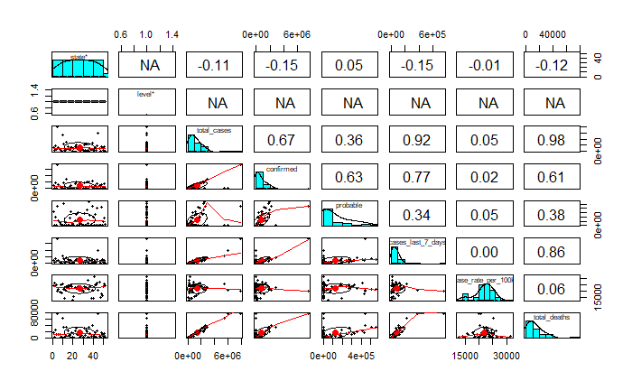

```r
library(psych)
suppressWarnings(pairs.panels(data.df))
```

### Part 2.1-iv-a

Question: Why should we exclude the first two columns from correlation analysis?

Answer: The first two columns are string data. So, we must exclude them in correlation analysis.

### Part 2.1-iv-b

Question: Which pair of columns have the highest correlation?

Answer: total_cases and total_deaths have highest correlation of 0.98

### Part 2.1-v-a

```r
options(scipen = 999)
plot(data.df$probable,data.df$total_deaths, xlab="Probable Cases", ylab="Total Deaths", xlim =c(0,600000), ylim = c(0, 80000),pch =16,)
par(new = TRUE)
```

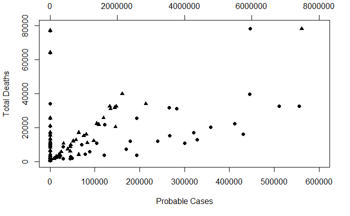

```r
plot(data.df$confirmed, data.df$total_deaths, axes = FALSE, xlab = "", ylab = "",xlim = c(0,8000000), ylim = c(0, 80000),pch =17)
axis(side = 3, at = pretty(range(data.df$confirmed)))
```